# STA 141A: Predicting Wildfire Incidence in the United States

Josiah Tolbert

March 16, 2026

# Abstract

Wildfires across the United States pose an extended threat to livestock, human infrastructure, and safety to the general population. Wildfires are often unpredictable large-scale natural disasters that displace millions from their homes every year with little to no warning.

Being able to predict *when* and *where* these wildfires may breakout is imperative to thwarting this concerning wildfire outbreak issue. This project developed a **binary classification system** using notable wildfire outbreaks in historical U.S wildfire dataset sourced from **a subset of the 188 million US wildfires historical records**. By evaluating spatial, temporal, and historical data the predictor model was sought out to be able to predict when and where a wildfire may outbreak.

An **XGBoost model** was implemented against a baseline logistic regression model both using the predictors of latitude, longitude, and month of the fire outbreak. Additional historical information was added including a 12 month rolling size history and 3 month rolling siz count as to avoid data leakage. The model consistently outperformed the baseline model confirms the importance of these predictors.

### Abstract: Key Insights

- 100k Wildfire data sourced from *a subset of the 188 million US wildfires historical records*
- Data cleaned and pre-processed to remove irrelevant columns
- **Latitude and Longitude** used to create spatial grids for geographic data
- Date column used to form **Discovery Month** Column for temporal data
- Binary outcome column **‘y_next’** created per spatial temporal grid cell (1 degree grid per month/year with ‘floor()’)
- Implemented XGBoost model which outperformed baseline model analysis
- Expanding-window cross validation ensures no temporal data leakage in 20 total annual folds
- Geographic **Longitude** and **Latitude** data revealed to be the strongest predictor with spatial months and historical second in 2nd and third in terms of improtance..

# 1. Data Preprocessing

## 1.1: Handling edge cases, missing information, and selecting predictors

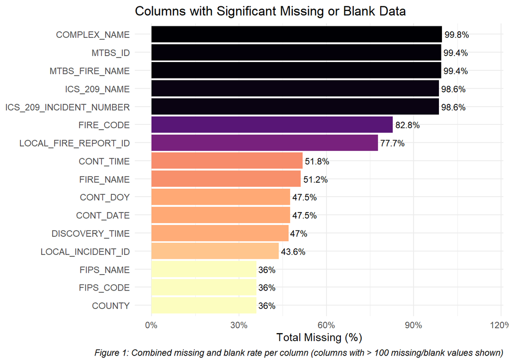

The thorough analysis began with a hearty summarize function and corresponding figure (*Figure 1*) pictured above. Of the 39 columns in the original dataset only 16 had Missing, blank, or unusual “0” responses - These can be located in Figure 1 above under the “Variable” column.

Within these 16 missing columns **‘COMPLEX_NAME’, ‘MTBS_FIRE_NAME’, and ‘ICS_209_NAME’**, all featured over a **98.5%** missing data rate and would largely be unreliable for use in further analysis. With the 36 left there was a systematic approach to determining which columns could formally stay.

**Click to expand: Column Removal Detail Table**

Of the 39 total columns *Figure 1* above isolates the variables with significant quality concerns namely ‘COMPLEX_NAME’,‘MTBS_FIRE_NAME’, and ‘ICS_209_NAME’ all exceed 98.5% missing rates and are thus unusable. The ‘COUNTY’ Column is missing nearly 1/3 of it’s total data making it unusable as a spatial predictor. These predictors were removed on three major basis depending on an issue with future modeling. For this reason ‘LATITUDE’ and ‘LONGITUDE’ were selected as the preliminary spatial units as they are not missing a notable amount of data.

1. **Data leakage**: Columns that had variables that were recorded after a fire breaks out, these cannot be used as predictors to prevent the model from cheating *(e.g, ‘FIRE_SIZE_CLASS’,‘STAT_CAUSE_CODE’,‘CONT_TIME’)*
2. **Multicolinearity**: With **‘LATITUDE’** and ‘**LONGITUDE**’ Being selected as the primary spatial units, other overlapping geographic coordinates were removed to prevent the model from overfitting on known data. *(e.g, ‘OWNER_CODE’,‘COUNTY’,‘FIPS_NAME’)*
3. **Administrative identifiers**: These were columns with predictive value as they are traditionally randomly assigned and only for high level fire administrative work *(e.g, ‘FPA_ID’,‘FIRE_NAME’,‘MTBS_ID’)*

This confirms the heavy amount of data preprocessing necessary to have accurate and relevant data in our analysis.

## 1.3: Constructing space-time units, predictors, and the binary outcome.

*Slide_sum methodology adopted from STA 141 Discussion for identical Baseline model<sup>[2]</sup>*

**Spatial Grid:**Creating the **spatial temporal** matrix required the creation of **two unique dataframes**. The first half was the spatial side with **longitude** and **latitude** rounded to the first degree to create 1x1 degree latitude longitude grid cells with the `floor()` feature. This gave us **523** unique grid cells that have recorded at least 1 notable fire.

**Temporal grid:** For the temporal half the max and min years (1992 - 2015) was calculated from the dataset and **‘Discovery DOY’** was used in conjunction with **‘FIRE_YEAR’** and conversion to date formatting to properly retrieve the specific month out of the year. Then the sin and cos of each month was formed to ensure that the model can recognize that while December and Janaury are 11 units a part they are truly bordering months.

**Temporal Spatial Grid:** Using both created temporary data frames the `cross_join()` function was used to take the **Cartesian product** of the temporal and spatial grid to get **150101** unique spatial grids derived from the latitude and longitude data.

**Additional Predictors**: Additional predictors regarding the rolling count and size counts of 3, and 12 were created to form rolling memory to prevent future data leakage. The data is able to see the most recent data leading up to a month to make a new predictor on status of a fire given recent previous fires. Size_roll12 accounts for the size of wildfires over the last year, while Fire_roll 12 and 3 account for the *amount* of fire over the last 12 and 3 months respectively. An after = -1 was created to prevent immediate leakage.

In this manner the main predictors were formally constructed with discovery month being formed through the temporal analysis and construction while **longitude** and **latitude** were formed by the spatial construction.

**Binary outcome `y_next`**: For each grid cell, month `y_next = 1` if at least one notable wildfire occurs in that grid cell during the follow month, if not it receives a 0 for no. The `lead()` function is created to avoid the same month data leakage issue.

The created **binary check system** with the outcome percentage being 0.875%. Only 1314 out of 150101 observations have a fire in the next month of their occurrence. This confirms the extreme class imbalance suggested in section 1.2. This confirms that a model such as **XGBoost** may be necessary to prevent false negative with the `scale_pos_weight` parameter to avoid always predicting “no fire”

## 1.4: Data Preprocessing Summary

Table 2: predictor variables and Model Assignment

| Predictor | Description | Used In |
| --- | --- | --- |
| lat_bin | Grid latitude (1-degree floor bin) | Both |
| lon_bin | Grid longitude (1-degree floor bin) | Both |
| month_sin | Cyclical sine of DISCOVERY_MONTH | Both |
| month_cos | Cyclical cosine of DISCOVERY_MONTH | Both |
| fire_roll12 | Rolling fire count over past 12 months | Both |
| state | Majority state for grid cell (Which state is this?) | XGB |
| fire_roll3 | rolling fire count over past 3 months | XGB |
| size_roll12 | rolling total burn area over past 12 months | XGB |

Note:  
Blue rows = Baseline Model, pink = XGB booost

Table 2 above focuses final table of all descriptive predictors, the first five light blue predictors will be featured in the strict BASELINE model while the pink predictors were specifically created to be used with the future XGBoost model. **Fire_roll3** captures short-term fire persistence, and **size_roll12** captures whether historically large burns evaluate a greater chance of another fire via burned ground.

## 1.5 Total Data summary table

[output not shown]

*Table 3: Total metadata*

## Table 3 is the comprehensive summary of the model metadata, the range of year 1992-2015, and all predictors outlined once more for clarity.

# 2. Exploratory Data Analysis

## 2.1 United States Heatmap

To visualize the Implications of potential fires by location (**Latitude and longitude**) grid was created using the United states map data to view by grid. A **U.S heatmap** was created to see the total expanse of ignition count by location to visualize any potential spatial patterns in the wildfires dataset

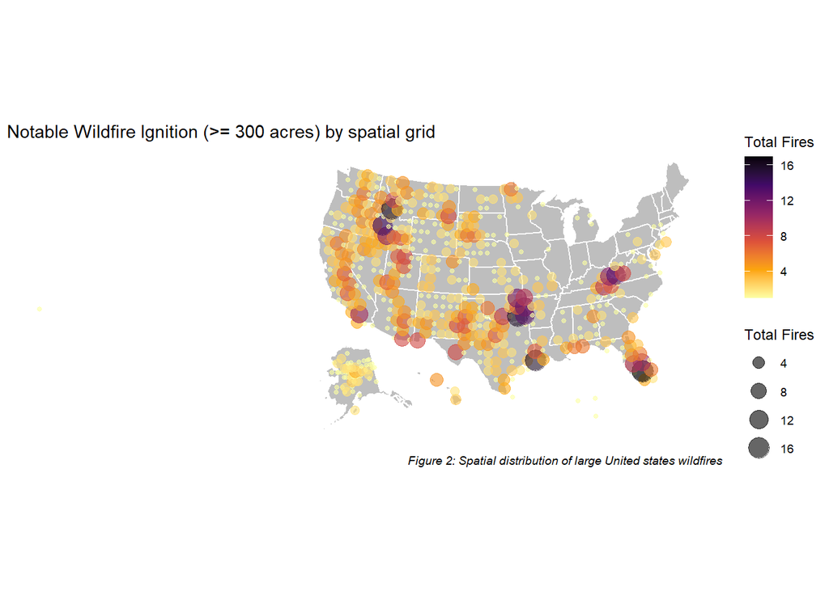

*USMAP Referenced<sup>[1]</sup>*

Certain grids cells and states carry a much higher baseline risk than other states which we can assume are from locals and weather patterns of the surrounding area.

## 2.2 Temporal Fire probability - Seasonal

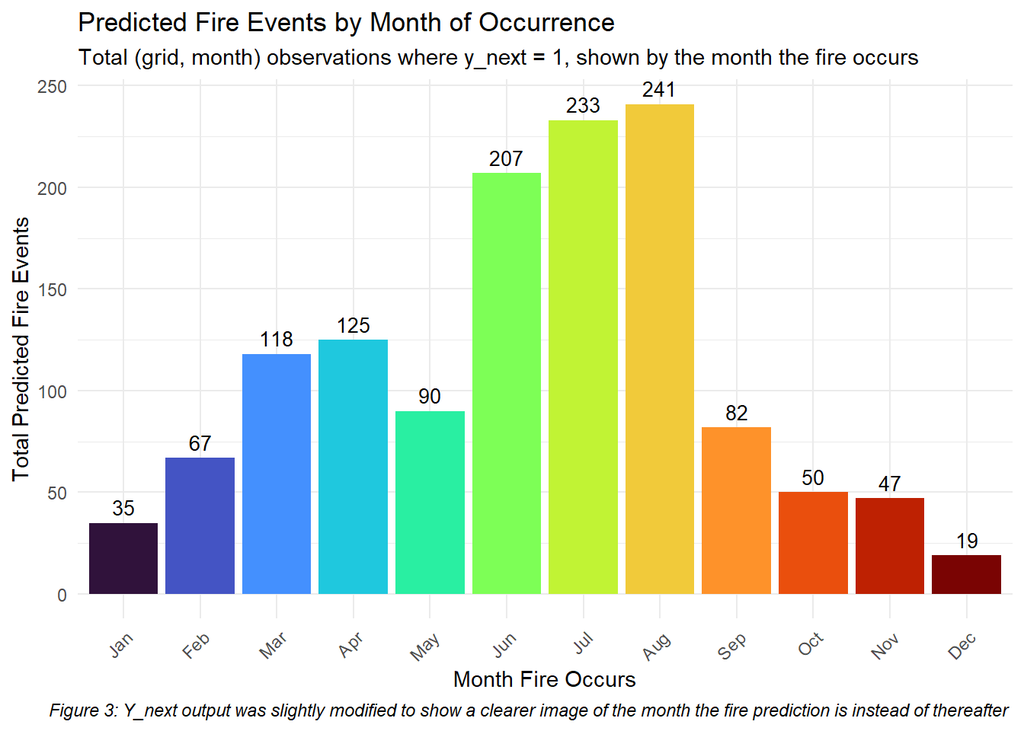

*Figure 3* Shows a clear seasonal pattern with **June, July, and August** having a massive spike that sharply declines in the fall winter. This leads to the seasonality of wildfires directly correlating with heat and temperature in the summer months compared to the wet and cold patterns found in the winter. This confirms that going with the cylindrical month encoding **month_sin, month_cos** rather than treating month as a raw number is directly responsible for helping the model learn as **December** and **January** are adjacent with close results. It better reflects the actual annual cycle.

## 2.3 Annual trends + Notable states

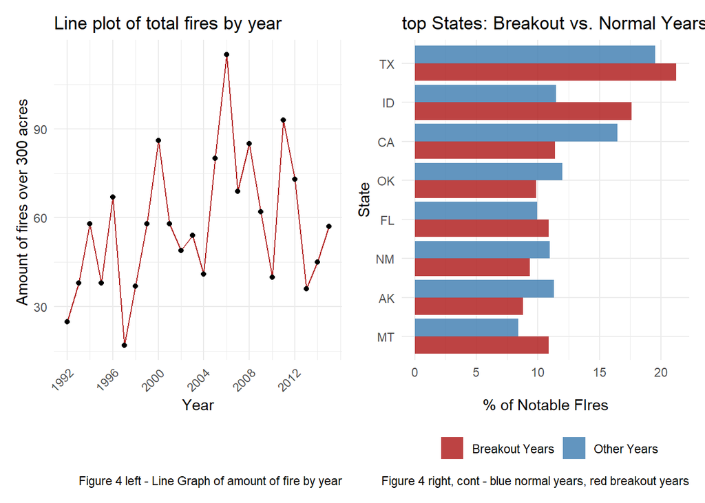

# 3. Modeling

## 3.1 Baseline Model

The Baseline model was selected with the response variable as the binary “y_next” (whether a fire will happen next month) column defined in section 1 with the predictor variables being as follows: spatial coordinates (`lat_bin`, `lon_bin`), cyclical month encoding (`month_sin`, `month_cos`), and a 12-month rolling fire count (`fire_roll12`).

Baseline Model prediction probability formula:
$$p_i = P(y\_next_i = 1 \mid \mathbf{x}_i)$$
Formal Baseline Model:

$$\log\left(\frac{p_i}{1-p_i}\right) = \beta_0 + \beta_1 \cdot
\text{lat.bin}_{i} + \beta_2 \cdot \text{lon.bin}_{i} + \beta_3 \cdot
\text{month.cos}_{i} + \beta_4 \cdot \text{month.sin}_{i} + \beta_5
\cdot \text{fire.roll12}_{i}$$

## 3.2 Model of Choice: XGboost

The **XGboost model**(Extreme Gradient boosting) model is an ensemble learning method that builds sequential decision trees to minimize classifications errors. Unlike the standard logistic regression model the XGBoost model can capture **nonlinear relationships and interactions** between predictors such as the interaction specific a specific grid cell and recent fire history.

As noted prior the logistic regression model is heavily susceptible to our data’s extreme class imbalance when can also be offset with the `Scale_pos_weight()` function. In addition to this the XGBoost model will have 3 more predictors than the baseline being

- **`state`** - captures state level policy such as vegetation, climate, policy, and urban density
- **`fire_roll3`** - captures short-term fire cluster effect to see if a fire causes sequential fires
- **`size_roll12`** - captures whether historically large burns evaluate future risk or dampen the risk of further flames by charring land.

For our binary classification task, the model outputs a predicted probability $\hat{p}_i$ per instance i by summing up the prediction of the K (additive trees) and applying the logistic sigmoid :

$$\hat{p}_i = \frac{1}{1 + e^{-\hat{y}_i}} \quad \text{where} \quad
\hat{y}_i = \sum_{k=1}^K f_k(x_i), \quad f_k \in \mathcal{F}$$
Here the $X_i$ represents our our full predicted vector set (spatial, seasonal, and all lagged behind fire history features) and $\mathcal{F}$ is the space of all possible decision trees. After doing so the model is able to minimize the the regularized objective:
$$\text{Obj} = \sum_{i=1}^n L(y_i, \hat{p}_i) + \sum_{k=1}^K \Omega(f_k)$$
Where $L(y_i, \hat{p}_i)$ is the log loss measuring the difference between the true fire occur $y_i$ and the predicted probability $\hat{p}_i$. $\Omega(f_k)$ is the regularization term mentioned earlier that penalize the tree for being complexity to prevent overfitting from the severe class imbalance.

### 3.3 XGboost Training Schematic

1. Initialization with base prediction (log odds of the class ratio)
2. Iterative boosting: For $K = 1$ to 500 rounds:
1. Compute residuals (gradient of the loss)
2. Fit new decision tree to these residuals
3. Add this new tree to the model with learning rate of $n = 0.1$ selected to prevent overfitting
3. Output: the final prediction is weighted sum of all 500 trees pass through the logistic function

# 4. Model Fitting and Validation

## 4.1 Time-Aware Expanding window cross validation

**Click to expand: Full Fold by Fold AUC Results (Table 4)**

Table 4: Expanding-Window Cross-Validation AUC Results

| Train Through | Validate On | Baseline AUC | XGBoost AUC |
| --- | --- | --- | --- |
| 1994 | 1995 | 0.678 | 0.791 |
| 1995 | 1996 | 0.675 | 0.771 |
| 1996 | 1997 | 0.805 | 0.795 |
| 1997 | 1998 | 0.785 | 0.818 |
| 1998 | 1999 | 0.636 | 0.637 |
| 1999 | 2000 | 0.646 | 0.705 |
| 2000 | 2001 | 0.707 | 0.757 |
| 2001 | 2002 | 0.652 | 0.721 |
| 2002 | 2003 | 0.716 | 0.771 |
| 2003 | 2004 | 0.662 | 0.743 |
| 2004 | 2005 | 0.635 | 0.757 |
| 2005 | 2006 | 0.704 | 0.697 |
| 2006 | 2007 | 0.611 | 0.677 |
| 2007 | 2008 | 0.614 | 0.692 |
| 2008 | 2009 | 0.675 | 0.663 |
| 2009 | 2010 | 0.670 | 0.692 |
| 2010 | 2011 | 0.683 | 0.728 |
| 2011 | 2012 | 0.668 | 0.698 |
| 2012 | 2013 | 0.689 | 0.691 |
| 2013 | 2014 | 0.733 | 0.754 |

Note:  
Each fold trains on all data up to the listed year and validates on the next year.

*Expanding cross validation loosely based on R documentation from tidyverse <sup>[3]</sup>*

## 4.2 Expanding Window AUC Validation results and comparison

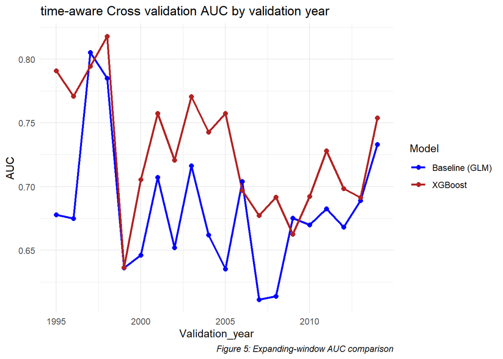

## 4.3 Tracking overall variable importance

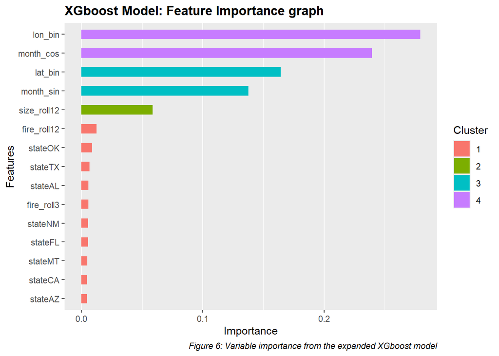

Overall this graphs represents how spatial and temporal predictor are the most relevant to strengthening the model for classic predictors. In terms of rolling or lagged averages the size_roll12 or metric of total area burned is the strongest to be measured when gauging historical data.

## 4.4 Training loss diagnostic

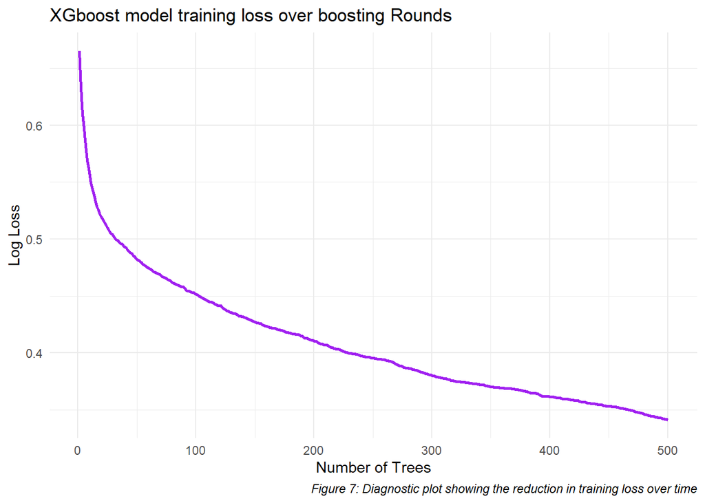

## 4.5 Model performance summary

| Model | Description | Predictors | Avg. CV AUC |
| --- | --- | --- | --- |
| **Baseline** | Logistic Regression (TA specification) | 5 | **0.682** |
| **XGBoost** | Gradient Boosted Trees (500 rounds) | 8 | **0.728** |

*Table 5: Average AUC across all the expanding window folds*

*Table 5* Reveals that the XGboost model outperforms the baseline model by **0.046 AUC points**(**6.74%** relative improvement) averaged across all validations years. This demonstrates that the three additional predictors added to the model to show historical burn area, short term fire clustering, and state functionality were all meaningful to capture patterns and aid predictability to the XGBoost model.

# 5. Summary

## 5.1 Data preparation and filtering

In summary, the goal to obtain a strong predictor model to determine wildfire occurrence in future months across land and time was a success. The raw dataset of **100,000** wildfire records was filtered to **1381** notable fires (>= 300 acres). A 1 degree **spatial grid** was constructed an all grid cells that had ever recorded a fire in the year constraints of 1992 - 2015 were included. for a total of **150101** observations. The binary outcome **`y_next`** was created to predict whether a fire occurs in the specific grid cell ** next month** avoiding the same month leakage issue. Eight total predictors were engineered across three specify groups: spatial (lat, lon, state), seasonal (cyclical month encoding), and lagged fire history (3-month and 12-month rolling counts and burn area) these were spliced between the two models.

## 5.3 Modeling Results

**Final Results Table**

| Model | Description | Test AUC Score | predictor amount |
| --- | --- | --- | --- |
| **Baseline** | Logistic Regression | 0.682 | 5 |
| **XGBoost** | Advanced Gradiant Boost | 0.728 | 8 (Baseline + 3 new ) |

*Table 6: Final Results AUC*

The **XGboost** consistently outperformed the baseline logistic regression across the expanding window cross validation with **~20 annual folds**. The improvement highlights th effectiveness of the XGboost model being able to draw interactions between complex predictors such as a cells **recent fire history, geographic locations, and current season**. Something the base logistic regression model is unable to do. Additionally Unlike a traditional Random Forest model it circumvents the massive RAM needed to account for nearly **a million possible entries** by mathematically sourcing the best. This surpassed the base model cementing the **XGboost** model as the best for predicting future wildfire outbreaks.

Finally the **variable importance plot** revealed that the strongest predictor was longitude with latitude with discovery month and previous fire size history following closely behind. This confirmed that while the **seasonal data** was important to predicting the mode, the spatial data had the strongest effect in determining if a fire outbreak would occur at any given point. Though the previous outbreak size history is strong enough to be relevant for **predictive analysis**.

## 5.4 Final Summary

# Reference

[1] Di Lorenzo, P. US maps *Including Alaska and Hawaii* R package and documentation https://usmap.dev

[2] UC Davis STA 141 Discussion 9 & 10

[3] R documentation from tidyverse purr documentation for large influence: https://purrr.tidyverse.org/reference/map2.html